# **Less iteration, better charts** Rethinking how we create visualizations

Joseph Barbier - *Rome R Users Group, 2026*

## We’re doing things all wrong…

- Iteration has always been part of chart-making
- AI has accelerated this loop dramatically
- **But faster iteration ≠ better outcomes**
- We should invert the process → **design first, code last**

## The default workflow

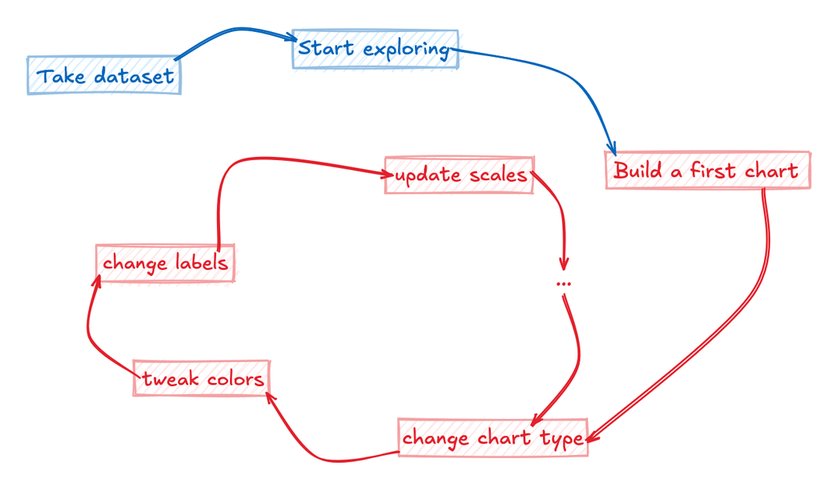

## Why this feels natural

- Tools/AI encourage it: *“I’ll just ask AI to do it to see how it looks”*
- Immediate feedback loop
- Feels productive (but is it?)

## Instead

> *Why does this chart need to exist?*
- **Audience** → who is this for?
- **Message** → what should they understand?
- **Decision / action** → what changes after seeing it?

# Design before code

## About

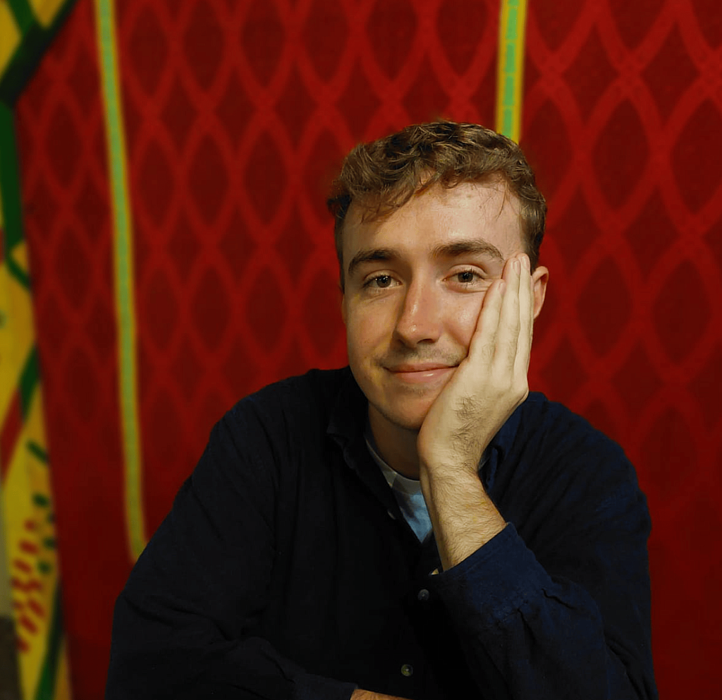

*Joseph*

barbierjoseph.com

ysunflower.com

Consulting

Open source

Data(viz)

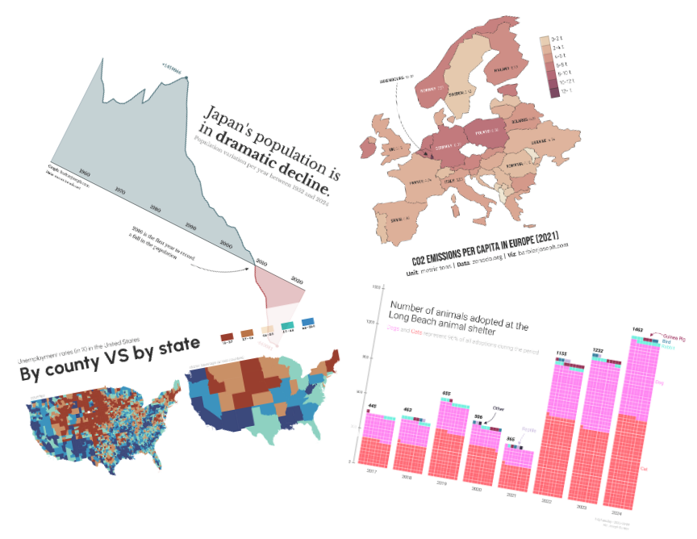

## Example

```r
df |> head() |> gt()
```

| date | price | unit_sold | sales |
| --- | --- | --- | --- |
| 2023-04-07 | 99.44 | 323.4315 | 32162.03 |
| 2023-04-14 | 99.77 | 318.3910 | 31765.87 |
| 2023-04-21 | 101.56 | 323.1703 | 32821.17 |
| 2023-04-28 | 100.07 | 318.0495 | 31827.22 |
| 2023-05-05 | 100.13 | 325.1213 | 32554.40 |
| 2023-05-12 | 101.72 | 312.8675 | 31824.89 |

**Context**:

- The company increased its price a few months ago from ~$100 to ~$115
- Management wants to know the impact
- *What should we do?*

## Let’s check units sold

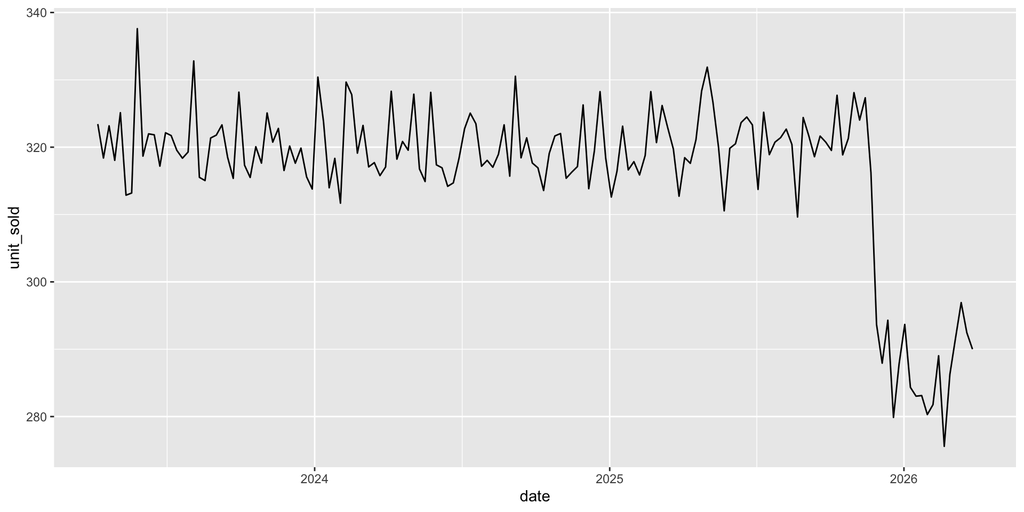

```r
ggplot(df, aes(x = date, y = unit_sold)) + geom_line()
```

Far fewer units sold!

## How about sales?

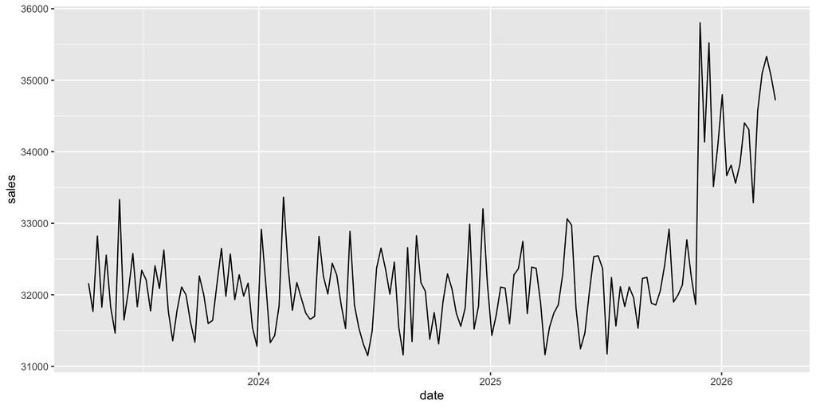

```r
ggplot(df, aes(x = date, y = sales)) + geom_line()
```

But much higher sales!

## Let’s compare them!

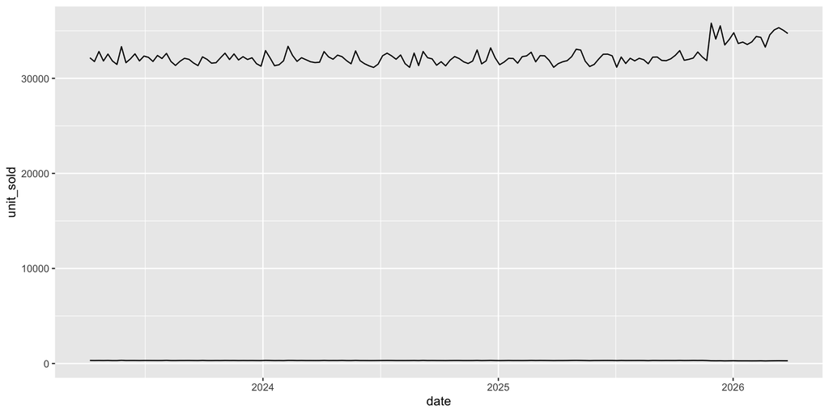

```r
ggplot(df, aes(x = date)) +
    geom_line(aes(y = unit_sold)) +
    geom_line(aes(y = sales))
```

Wait, what?

## Let’s put them next to each other

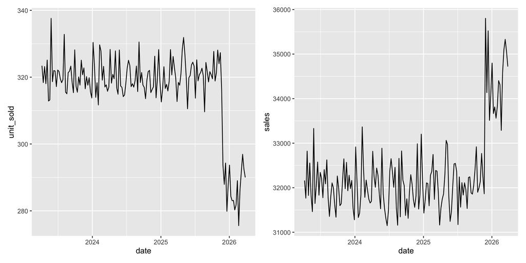

```r
units_sold <- ggplot(df, aes(x = date, y = unit_sold)) + geom_line()
sales <- ggplot(df, aes(x = date, y = sales)) + geom_line()
units_sold + sales
```

What a diff! Oh wait, the scale is weird!

## Adjust the scale

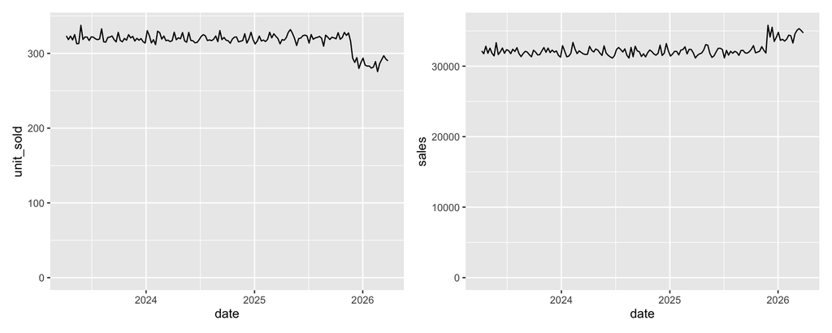

```r
units_sold <- ggplot(df, aes(x = date, y = unit_sold)) +
    geom_line() +
    ylim(0, NA)
sales <- ggplot(df, aes(x = date, y = sales)) + geom_line() + ylim(0, NA)
units_sold + sales
```

Better, but most of the data is useless here

## Reduce time period

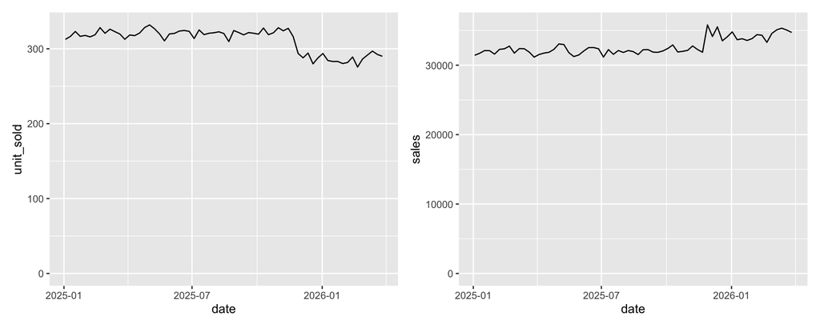

```r
df_filter <- df |> filter(date >= "2025-01-01")
units_sold <- ggplot(df_filter, aes(x = date, y = unit_sold)) +
    geom_line() +
    ylim(0, NA)
sales <- ggplot(df_filter, aes(x = date, y = sales)) + geom_line() + ylim(0, NA)
units_sold + sales
```

The trend isn’t really obvious now…

## Let’s try to put them on the same chart

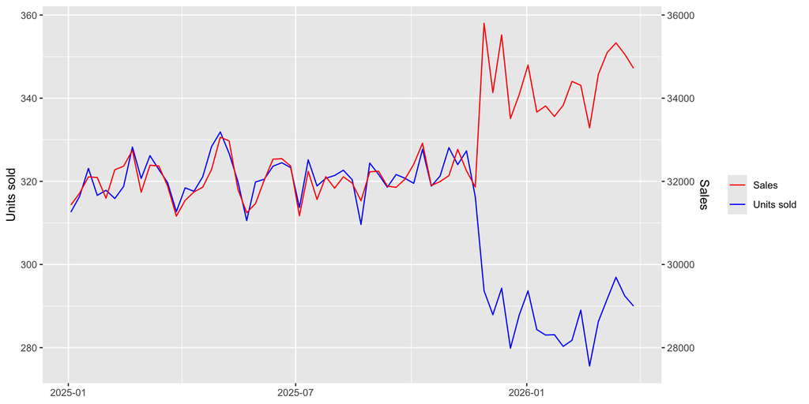

- Scenario 1
- Scenario 2
- Scenario 3
- Scenario 4
- Scenario 5

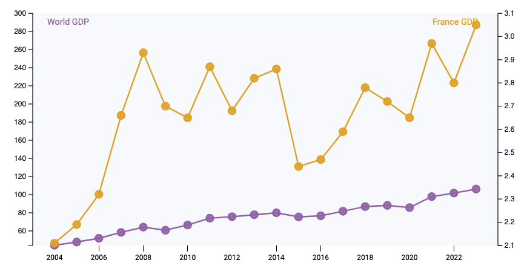

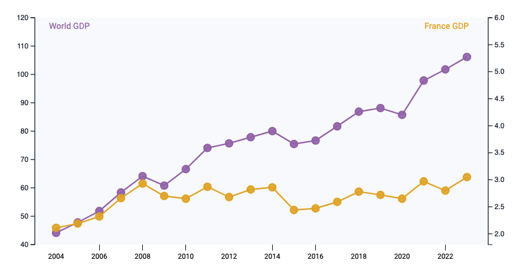

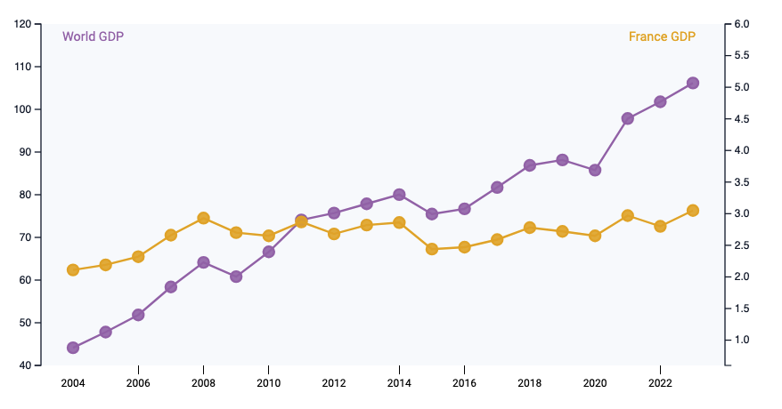

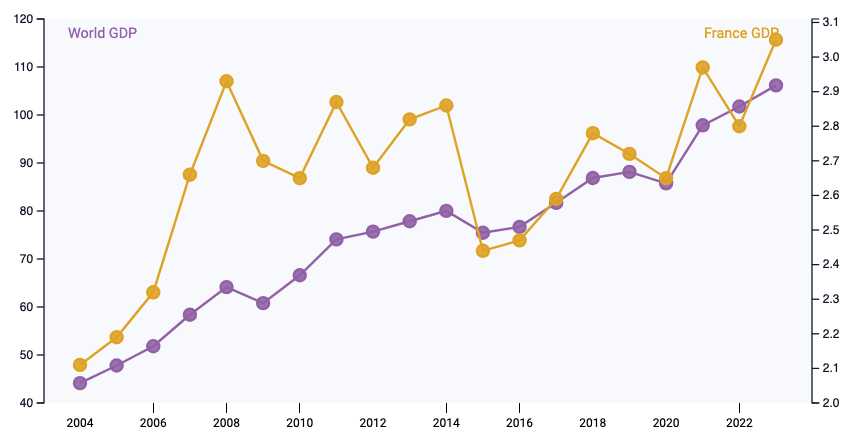

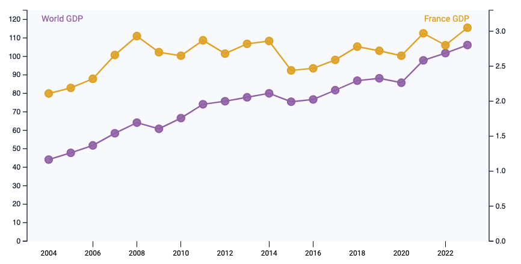

Sources:

- [react-graph-gallery.com](https://www.react-graph-gallery.com/example/dual-y-axis-interactive)
- [datawrapper.com](https://www.datawrapper.de/blog/dualaxis)

## But how do I compare them now?

### “Your scientists were so preoccupied with whether or not they could, that they didn’t stop to think if they should.” *Jurassic Park*

## Maybe we don’t need to?

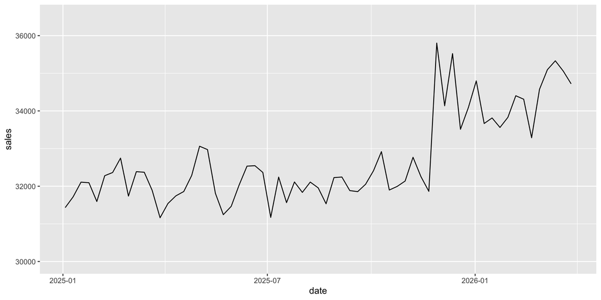

```r
p <- ggplot(df_filter, aes(x = date, y = sales)) +
    geom_line() +
    ylim(30000, 36500)
p
```

This chart should work with better styling and annotations

## Change the theme

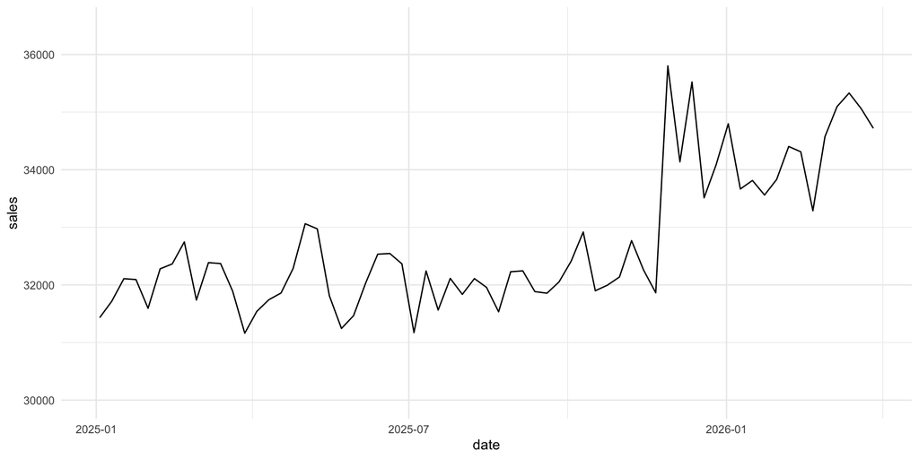

```r
p <- p + theme_minimal()
p
```

## Remove labels

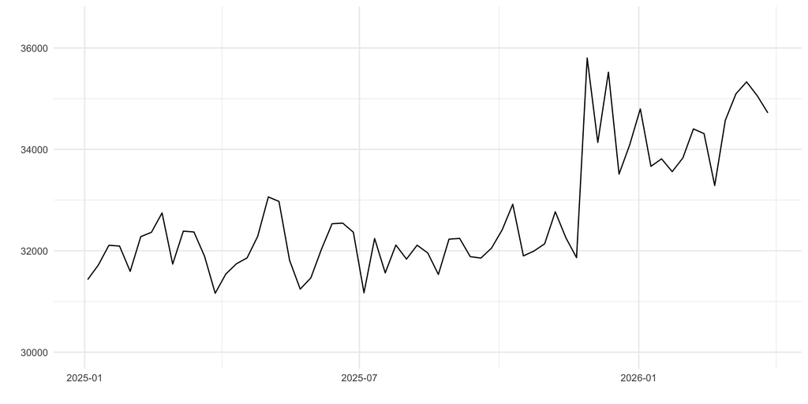

```r
p <- p + xlab("") + ylab("")
p
```

## Update labels

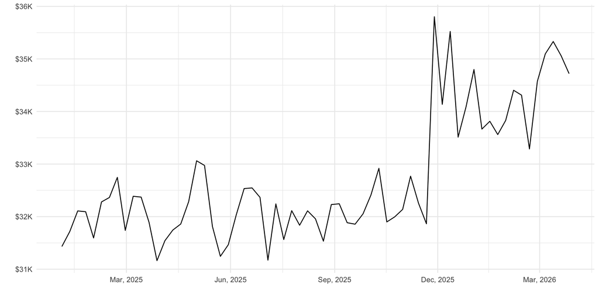

```r
p <- p +
    scale_y_continuous(labels = label_dollar(scale = 1e-3, suffix = "K")) +
    scale_x_date(labels = label_date("%b, %Y"), date_breaks = "3 months")
p
```

## Increase their size

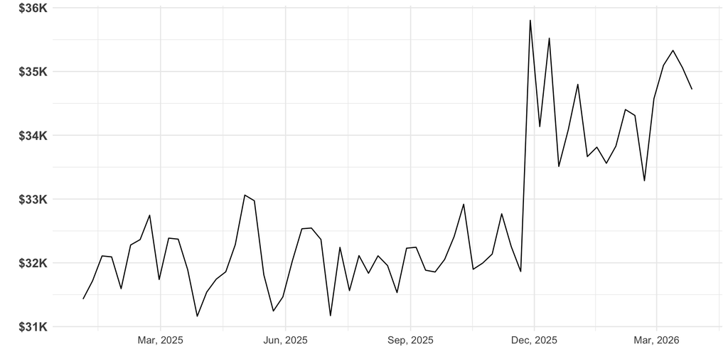

```r
p <- p +
    theme(
        axis.text.x = element_text(size = 10),
        axis.text.y = element_text(size = 12, face = "bold")
    )
p
```

## Highlight new price

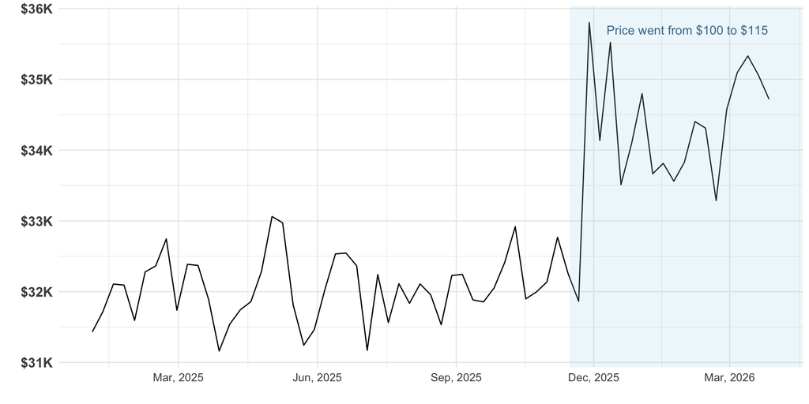

## Remove x grid

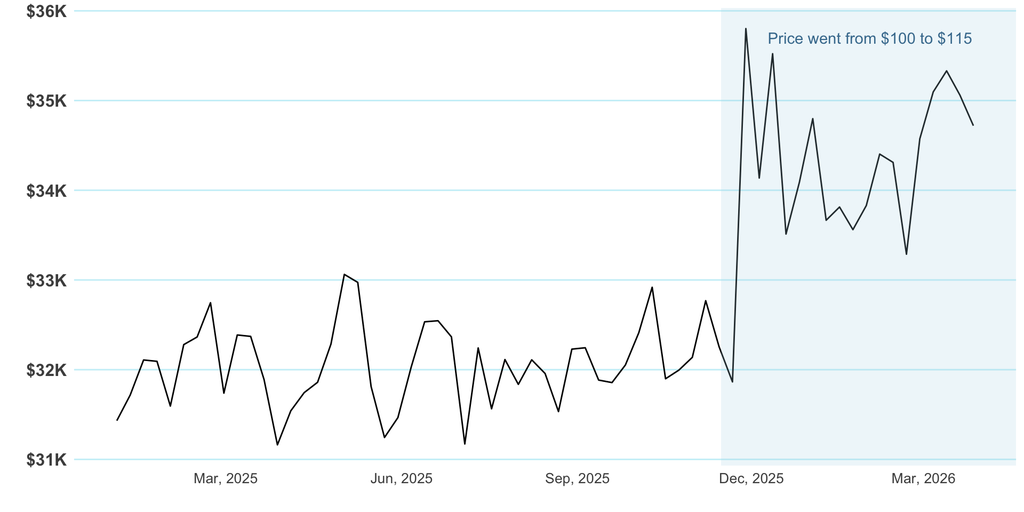

## Move to the right

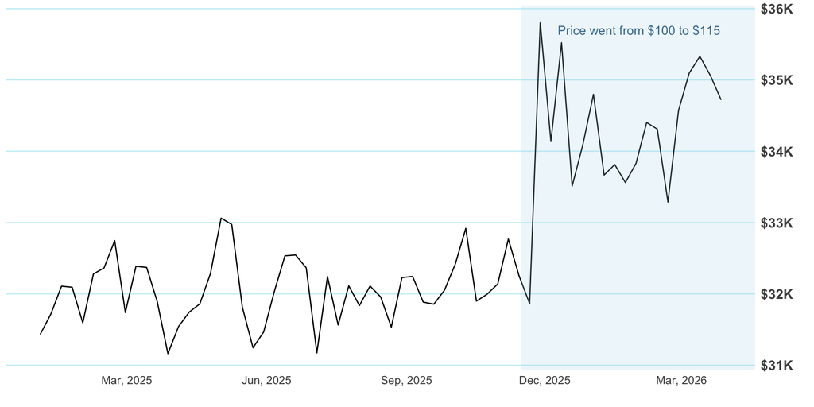

Getting better!

## A colleague arrives…

*“I think it’s important to also show units sold, and management wants a bar plot!”*

- Wait, so we need to start over?
- OK, let’s do a bar plot then!
- But what if management changes its mind?

## Let’s do it differently

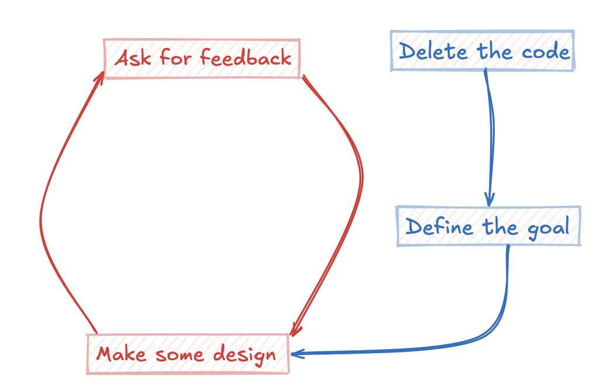

## Define the goal

- **Goal**: impact of the price change on:
  - units sold –> are we selling fewer units, and by how much?
  - sales –> are sales higher or lower, and by how much?

## Create a design

*Only rule: don’t rush it!*

- Figma
- Canva
- Excalidraw (personal preference)
- Pen and paper
- It doesn’t matter! Use whatever you prefer

## Create a design

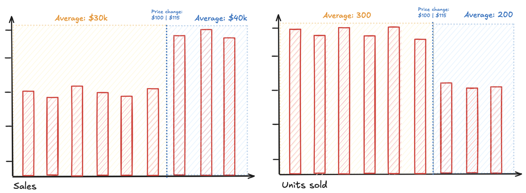

- This takes much less time
- Ask for feedback
- And repeat!

## Create a design

😱 Zero lines of code! Are we not productive???

- We just did **the hard part**

## Now we can code

- With AI
  - Weak prompt: *“Show sales evolution”*
  - Strong prompt: *“Create a bar plot for period X, highlight Y, remove Z, compare A and B, …”*
- Without AI
  - Much easier too!

## Framework

- Define intent
  - Who? What? Why?
- Define the design
  - If you can’t visualize it, you’re not ready to code yet!
- Feedback
  - Ask colleagues, managers, etc
- Code

## When is it okay to code first?

- Get an overview of the data
  - AI can be very useful here
- Design is already clear

Thanks for listening!

Did I say something wrong?

- Come chat!

Did I say anything relevant?

- Come chat!

Other?

- LinkedIn: Joseph Barbier
- email: `joseph@ysunflower.com`
- slides: [github.com/JosephBARBIERDARNAL/talk](https://github.com/JosephBARBIERDARNAL/talk/tree/main/src/rome-r-users-group)